# marginalization of OLINK data on age and sex

```python
import numpy as np
import matplotlib.pyplot as plt
import seaborn as sns
import pandas as pd
```

# 1. reading the data

```python
## first, grabbing molecule names from the original files (this is a bit dirty...)
df =pd.read_csv('data/Inflammation_Plasma_Etter.csv',sep=';', skiprows=[0,1,2,4,5,6] , index_col=0)
df.drop(columns=['Plate ID' , 'QC Warning'] , inplace=True)

inflammatoryMolecules = list( df.columns )

df =pd.read_csv('data/Neurology_Plasma_Etter.csv',sep=';', skiprows=[0,1,2,4,5,6] , index_col=0)
df.drop(columns=['Plate ID' , 'QC Warning'] , inplace=True)

neuroMolecules = list( df.columns )

## removing common molecules. we keep the ones in neuro
inter = set( inflammatoryMolecules ).intersection(neuroMolecules)
for c in inter:
    inflammatoryMolecules.remove(c)



print(len(inflammatoryMolecules))
print(len(neuroMolecules))

## now reading the molecular data
df_molecular = pd.read_csv( "imputed_data/ALL_imputed.csv" , index_col='Assay' )
df_molecular.head()
```

```
90
92
```

| Assay | CSF_NMNAT1 | CSF_NRP2 | CSF_MAPT | CSF_CADM3 | CSF_GDNF | CSF_UNC5C | CSF_VWC2 | CSF_Siglec-9 | CSF_CLM-6 | CSF_EZR | ... | Plasma_TNFRSF9 | Plasma_NT-3 | Plasma_TWEAK | Plasma_CCL20 | Plasma_ST1A1 | Plasma_STAMBP | Plasma_IL5 | Plasma_ADA | Plasma_TNFB | Plasma_CSF-1 |
| --- | --- | --- | --- | --- | --- | --- | --- | --- | --- | --- | --- | --- | --- | --- | --- | --- | --- | --- | --- | --- | --- |
| 6346 | 0.693481 | 7.09192 | 3.77791 | 7.91794 | 0.014267 | 4.42140 | 6.47501 | 4.05874 | 4.45070 | 3.10702 | ... | 5.18080 | 0.289609 | 7.50065 | 5.56492 | 0.181655 | 3.74292 | 0.014006 | 3.94051 | 3.01680 | 8.71467 |
| 4995 | 2.343750 | 7.47933 | 4.56933 | 8.15273 | 2.822150 | 4.79441 | 7.15407 | 4.73644 | 5.04218 | 3.18018 | ... | 7.23892 | 1.632950 | 7.74498 | 6.85531 | 0.181655 | 3.36869 | 0.014006 | 4.16263 | 4.28101 | 9.43810 |
| 5204 | 2.194830 | 7.48286 | 3.71677 | 8.08137 | 0.014267 | 4.18171 | 6.33081 | 4.14324 | 4.77651 | 3.58364 | ... | 5.87578 | 1.468700 | 7.78032 | 5.48079 | 1.675910 | 4.30579 | 0.014006 | 3.62264 | 3.30802 | 9.02096 |
| 5652 | 4.396180 | 7.18781 | 3.34626 | 8.07230 | 0.014267 | 4.73700 | 6.30346 | 4.30440 | 4.80531 | 4.52920 | ... | 5.58927 | 1.581910 | 7.53799 | 6.76732 | 0.181655 | 4.74582 | 0.014006 | 4.09798 | 4.16133 | 9.06270 |
| NC029 | 2.167530 | 6.15583 | 2.89508 | 7.61839 | 0.014267 | 3.67643 | 4.26698 | 2.86324 | 3.78789 | 2.50139 | ... | 5.56131 | 1.691930 | 7.85807 | 6.95975 | 0.181655 | 4.18115 | 0.014006 | 4.17950 | 4.16535 | 9.19906 |

5 rows × 364 columns

```python
# we replace the '-' and ' ' symbol with another character so it does not mess up with formulas
substChar = '_'
df_molecular.columns = df_molecular.columns.str.replace('-',substChar)
df_molecular.columns = df_molecular.columns.str.replace(' ',substChar)
```

```python
## and metadata
df_metadata = pd.read_csv('data/metadata.csv', index_col='studyID')
df_metadata.covid = df_metadata.covid.astype(bool)
df_metadata.Age = df_metadata.Age.astype(int)
df_metadata["stageGroup"] = df_metadata.Group
df_metadata.loc[df_metadata.covid==True , "stageGroup"] = df_metadata.Stage[df_metadata.covid == True]
#df_metadata$stageGroup = factor(df_metadata$stageGroup , levels = c("healthy control", "inflammatory control", "I",'II','III') )

df_metadata.head()
```

| studyID | Age | Sex | Group | Stage | covid | stageGroup |
| --- | --- | --- | --- | --- | --- | --- |
| 4927 | 38 | f | healthy control | I | False | healthy control |
| 5050 | 53 | m | healthy control | I | False | healthy control |
| 5052 | 22 | m | healthy control | I | False | healthy control |
| 5062 | 23 | m | healthy control | I | False | healthy control |
| 5092 | 47 | f | healthy control | I | False | healthy control |

```python
df_metadata.stageGroup.value_counts()
```

```
healthy control         25
inflammatory control    25
I                       18
III                     15
II                       7
Name: stageGroup, dtype: int64
```

```python
## merging

df_merged = pd.concat( [df_metadata,df_molecular] , axis=1 )
```

```python
df_molec_md = pd.read_csv("imputed_data/molecular_metadata.csv", index_col=0)
df_molec_md.index = df_molec_md.index.str.replace('-',substChar)
df_molec_md.index = df_molec_md.index.str.replace(' ',substChar)
df_molec_md.head()
```

|  | LOD | Missing Data freq. | Normalization | fractionMissing |
| --- | --- | --- | --- | --- |
| Plasma_NMNAT1 | 1.97144 | 9% | IPC Normalized | 0.088889 |
| Plasma_NRP2 | 0.57337 | 0% | IPC Normalized | 0.000000 |
| Plasma_MAPT | 1.53894 | 97% | IPC Normalized | 0.966667 |
| Plasma_CADM3 | 1.30957 | 0% | IPC Normalized | 0.000000 |
| Plasma_GDNF | 2.37159 | 78% | IPC Normalized | 0.777778 |

```python
df_molec_md.loc[ 'CSF_NMNAT1' , 'fractionMissing' ]
```

```
0.3222222222222222
```

# 2. neuroCOVID

## 2.1. linear modelling

Linear modelling on the log of expression (which is what NPX are) has been used in [Mudd et al., Sci. Adv. 2020](https://www.ncbi.nlm.nih.gov/pmc/articles/PMC7725462/) on similar data.

Such a model would allow to regress out co-variables such as sex or age, which is nice.

However to be interpretable such a model rely a several important hypothesis which may or may not be respected by our dataset. Our first goal is thus to perform a brief investigation of whether or not the assumptions of the models are respected.

```python
import statsmodels.api as sm
import statsmodels.formula.api as smf
```

```python
import scipy.stats as stats

normalTest_Pvals = []
residualMedians = []
fractionMissing = []
molecule = []

for molec in df_molecular.columns:
    print(molec)
    results = smf.ols(molec+' ~ Age + Sex + stageGroup', data=df_merged).fit()
#print( results.summary() )
    s,pval = stats.normaltest( results.resid )

    normalTest_Pvals.append(pval)
    residualMedians.append( results.resid.median() )
    fractionMissing.append( df_molec_md.loc[ molec , 'fractionMissing' ] )
    molecule.append(molec)
```

[output not shown]

[output cut: 309 more lines]

[output not shown]

```python
df_ml_assumptions = pd.DataFrame( {'normalTest_Pval' :normalTest_Pvals,
                                  'fractionMissing' : fractionMissing,
                                  'residualMedians' : residualMedians}, index= molecule )

m2 = df_ml_assumptions['normalTest_Pval'] <0.01
print("mnolecules whose residuals have a pval < 0.01 for the omnibus normal test (ie. rejection of normality)")
m2.value_counts()
```

```
mnolecules whose residuals have a pval < 0.01 for the omnibus normal test (ie. rejection of normality)
```

```
True     206
False    158
Name: normalTest_Pval, dtype: int64
```

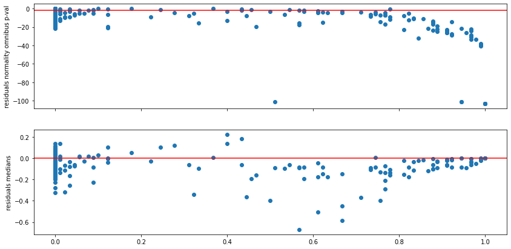

```python
fig, axes = plt.subplots(2,1 , figsize = (14,7) , sharex = True)

axes[0].plot(fractionMissing, np.log10(normalTest_Pvals) , 'o' )
axes[0].axhline(-2 , color='r')
axes[0].set_ylabel('residuals normality omnibus p-val')


axes[1].plot( fractionMissing, residualMedians , 'o' )
axes[1].axhline(0 , color='r')
axes[1].set_ylabel('residuals medians')
```

There is a manifest link between missing data and non-respect of the model assumptions.

Nevertheless, even with no missing data many molecules do not pass the test.

With this being said, the assumption of normality is not the most important one here, and the fact that residuals medians are mostly close to 0 is a good point.

```python
df_ml_assumptions = pd.DataFrame( {'normalTest_Pval' :normalTest_Pvals,
                                  'fractionMissing' : fractionMissing,
                                  'residualMedians' : residualMedians}, index= molecule )
m1 = df_ml_assumptions['fractionMissing'] <0.1
m2 = df_ml_assumptions['normalTest_Pval'] >0.01

df_ml_assumptions.loc[ m1 & m2, : ]
```

|  | normalTest_Pval | fractionMissing | residualMedians |
| --- | --- | --- | --- |
| CSF_NRP2 | 0.076145 | 0.0 | 0.019115 |
| CSF_UNC5C | 0.255281 | 0.0 | 0.068942 |
| CSF_VWC2 | 0.024304 | 0.0 | 0.054559 |
| CSF_Siglec_9 | 0.014338 | 0.0 | -0.036789 |
| CSF_CLM_6 | 0.080514 | 0.0 | -0.059757 |
| ... | ... | ... | ... |
| Plasma_CX3CL1 | 0.396190 | 0.0 | 0.009774 |
| Plasma_TWEAK | 0.065711 | 0.0 | -0.014418 |
| Plasma_STAMBP | 0.104851 | 0.0 | -0.027377 |
| Plasma_ADA | 0.140960 | 0.0 | -0.047889 |
| Plasma_CSF_1 | 0.134466 | 0.0 | 0.003704 |

147 rows × 3 columns

The alternative to linear modelling do not make such assumptions, however they limit our ablity to regress out the sex and age.

Let's look at how age is spread among the different groups

```
stageGroup
I                       48.111111
II                      49.000000
III                     62.200000
healthy control         50.600000
inflammatory control    53.320000
Name: Age, dtype: float64
```

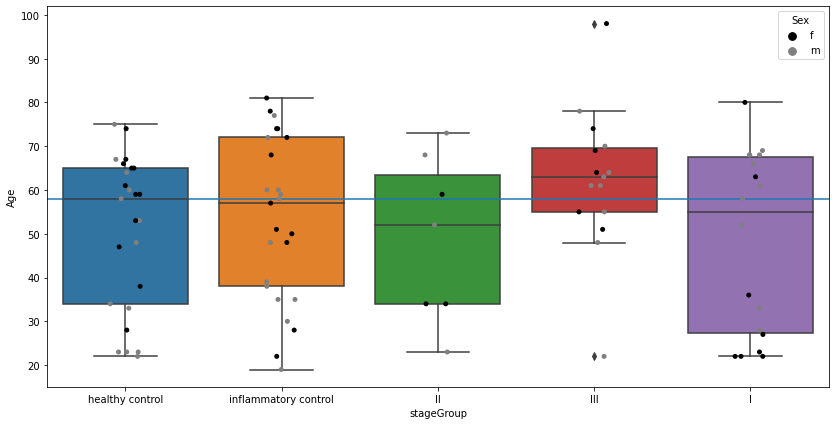

```python
import seaborn as sns
fig,ax = plt.subplots(figsize=(14,7))
sns.boxplot( x = "stageGroup" , y = "Age" , data = df_metadata , ax=ax)
sns.stripplot( x = "stageGroup" , y = "Age" , hue='Sex', data = df_metadata,ax=ax , palette = ['black','grey'])
ax.axhline( df_metadata.Age.median() )

df_metadata.groupby("stageGroup").Age.mean()
```

There is, unfortunately, a manifest imbalance there.

**IMPORTANT NOTE** what is shown above is by no mean a thorough and valid analysis. Rather it is a data exploration which is meant to give an intuition on the possible marginal effect of age when performing group comparison.

**Conclusion** when it comes to neuroCOVID stage, the model assumptions do not seem to be met with enough consistency for us to deploy this strategy and then rely on the group specific parameters to effect the testing.

Instead, we would perform a linear model, and extract the values marginalized on age and sex for each group and perform a non-parametric test on that.

NB : The effect of age is deemed real, but quite moderate.

## 2.2. marginalization of Age and Sex

```python
df_merged["CSF_TNFRSF11B"] = df_merged.CSF_OPG
df_merged["Plasma_TNFRSF11B"] = df_merged.Plasma_OPG
```

```python
palette5 = {'III' :'#073B4C',
    'II' : '#118AB2',
       'I' : '#06D6A0',
    'healthy control' : '#FFCE5C',
    'inflammatory control' : '#F26989' }

order5 = ['healthy control','inflammatory control','I','II','III']


## thankfully, the global median value is plausible for all categories (ie. close the the group medians and observed points)
medianAge = df_metadata.Age.median()

ageDiff = df_merged.Age - medianAge
sexDiff = df_merged.Sex == 'm'
```

```python
marginalizedVals = {}

for molec in df_molecular.columns:
    results = smf.ols(molec+' ~ Age + Sex + stageGroup', data=df_merged).fit()

    ## using the model parameters to marginalize
    diffReference = sexDiff*results.params['Sex[T.m]'] + ageDiff*results.params['Age']

    marginalizedValues = df_merged[molec] - diffReference

    marginalizedVals[molec] = marginalizedValues

    # Creating a report of the model and marginalization as a pdf
    fig = plt.figure( figsize=(14,28) )

    gs = fig.add_gridspec(4,2)
    ax1 = fig.add_subplot(gs[0, :]) # ols report
    ax2 = fig.add_subplot(gs[1, 0]) # fitted vs residuals
    ax3 = fig.add_subplot(gs[1, 1]) # fitted vs. observed
    ax4 = fig.add_subplot(gs[2, 0]) # marginalization effect
    ax5 = fig.add_subplot(gs[2, 1]) # histogram observed, marginalization
    ax6 = fig.add_subplot(gs[3, 0]) # boxplot observed
    ax7 = fig.add_subplot(gs[3, 1]) # boxplot marginalized



    ## reporting
    ax1.text( 0,0, str( results.summary() ) , font='monospace' )
    ax1.set_title( molec )
    ax1.axis('off')


    ax2.plot( results.fittedvalues, results.resid ,'o')
    ax2.axhline(0)
    ax2.set_xlabel('fitted values')
    ax2.set_ylabel('residuals')

    ax3.plot( results.fittedvalues, results.resid+results.fittedvalues ,'o')
    m = min(results.fittedvalues)
    M = max(results.fittedvalues)
    ax3.plot( [m,M] , [m,M] , color='red')
    ax3.set_xlabel('fitted values')
    ax3.set_ylabel('observed values')


    ax4.hist(diffReference)
    ax4.set_xlabel("marginalization effect")

    #ax5.hist( marginalizedValues , alpha = 0.5 , label="observed")
    #ax5.hist( df_merged[molec] , color='red', alpha = 0.5, label='marginalized')
    #ax5.set_xlabel(molec)
    #ax5.legend()
    m = min(df_merged[molec])
    M = max(df_merged[molec])
    ax5.scatter(df_merged[molec],marginalizedValues)
    ax5.plot( [m,M] , [m,M] , color='red')
    ax5.set_xlabel( "observed values" )
    ax5.set_xlabel( "marginalized values" )


    sns.boxplot( x="stageGroup" , y = molec , data=df_merged , ax = ax6  , order = order5 , palette = palette5)

    sns.boxplot( x="stageGroup" , y = marginalizedValues , data=df_merged , ax = ax7  , order = order5 , palette = palette5)
    ax7.set_ylabel("marginalized values")

    fig.savefig("images/marginalization/neuroCOVID/"+molec+"_marginalization_report.pdf")
    plt.close()
```

```python
df_marginal = pd.DataFrame( marginalizedVals )
df_marginal['stageGroup'] = df_merged['stageGroup']

df_marginal.head()
```

|  | CSF_NMNAT1 | CSF_NRP2 | CSF_MAPT | CSF_CADM3 | CSF_GDNF | CSF_UNC5C | CSF_VWC2 | CSF_Siglec_9 | CSF_CLM_6 | CSF_EZR | ... | Plasma_NT_3 | Plasma_TWEAK | Plasma_CCL20 | Plasma_ST1A1 | Plasma_STAMBP | Plasma_IL5 | Plasma_ADA | Plasma_TNFB | Plasma_CSF_1 | stageGroup |
| --- | --- | --- | --- | --- | --- | --- | --- | --- | --- | --- | --- | --- | --- | --- | --- | --- | --- | --- | --- | --- | --- |
| 4927 | 0.783146 | 7.484550 | 4.359968 | 8.166541 | 0.108638 | 4.733553 | 6.869538 | 4.009678 | 4.725901 | 3.476555 | ... | 1.409262 | 7.279297 | 5.418392 | 0.236511 | 3.412914 | -0.174867 | 3.895639 | 3.732914 | 9.023864 | healthy control |
| 5050 | 0.455615 | 7.286502 | 4.645233 | 8.172515 | 0.067673 | 5.256008 | 7.272363 | 4.442834 | 4.684212 | 2.823498 | ... | 2.027130 | 7.871435 | 5.936471 | 0.262972 | 3.278133 | 0.099333 | 4.329668 | 3.477081 | 8.744154 | healthy control |
| 5052 | 0.594596 | 6.635136 | 3.490066 | 8.149356 | 0.213948 | 4.224093 | 6.016119 | 3.294286 | 4.056793 | 2.549147 | ... | 1.921543 | 8.165437 | 5.642695 | 0.347999 | 3.302632 | -0.193420 | 4.360193 | 4.213483 | 9.061708 | healthy control |
| 5062 | 0.590112 | 6.957021 | 3.770465 | 8.076262 | 0.209230 | 4.521448 | 6.355951 | 4.349481 | 3.955589 | 3.046600 | ... | 1.807028 | 7.978211 | 7.307649 | 0.345256 | 3.686129 | -0.183977 | 4.093367 | 3.674123 | 8.769930 | healthy control |
| 5092 | 0.742797 | 6.781485 | 2.867935 | 8.159029 | 0.066171 | 3.937601 | 5.994287 | 3.071284 | 3.886460 | 2.290494 | ... | 0.251490 | 7.912914 | 6.293002 | 2.075751 | 3.948645 | -0.089874 | 3.962206 | 3.573228 | 8.686050 | healthy control |

5 rows × 365 columns

```python
df_marginal.to_csv("marginalized_data/data_marginalized_neuroCOVID.csv")
```